## Spring 2023 STAT 240 In-Person (Part 1) Midterm Solution

## Multiple Choice (24 points). Each problem is worth 3 points.

### Circle the correct answer or answers as indicated.

**Problem 1.** Which type of graph is typically most effective at displaying the relationship between two quantitative variables. **Circle one answer.**

(a) bar chart (b) density plot (c) histogram (d) scatter plot

**(d)** scatter plot

**Problem 2.** Which of the following commands calculate the proportion of missing values in a vector X? **Circle all correct answers.**

1. `mean(is.na(X))`
2. `mean(X == NA)`
3. `sum(X == NA) / count(X)`
4. `sum(is.na(X)) / length(X)`

**(a)** and **(d)**

**Problem 3.** Which are valid names for an R object? **Circle all correct answers.**

(a) `bucky_badger` (b) `1_bucky_badger` (c) `bucky_badger_1` (d) `bucky=badger`

**(a)** and **(c)**

**Problem 4.** Which command keeps all rows of the a data set `obesity` where the variable `n` is not missing, the variable `sex` is “female”, and the variable `age` is not “05-17”? **Circle one answer.**

1. `obesity %>% filter(n != NA, sex = "female", age != "05-17")`
2. `obesity %>% filter(n != NA, sex == "female", age == !"adult")`
3. `obesity %>% filter(!is.na(n), sex == "female", age == !"05-17")`
4. `obesity %>% filter(!is.na(n), sex == "female", age != "05-17")`

**(d)**

**Problem 5.** The plot of a histogram of a variable `X` from a data set `df` appears to be symmetric, bell-shaped, and centered near 0. The value of `df %>% summarize(sd = sd(X))` is `15.0`. Which numerical value will be closest to the result of `df %>% summarize(p = mean( between(X, -30, 30)))`? **Circle one answer.**

(a) 0 (b) 0.68 (c) 0.95 (d) 99

**(c)**

**Problem 6.** What is the output of the following command, (suppressing variable names), where March 8, 2023 is a Wednesday and August 3, 2023 is a Thursday? **Circle one answer.**

```
tibble(date = mdy("3/8/2023")) %>%
  summarize(day = day(date),
            wday = wday(date, label = TRUE),
            yday = yday(date),
            month = month(date, label = TRUE))
```

1. `8 Wed 67 Mar`
2. `8 67 Wed Mar`
3. `3 Thu 215 Aug`
4. `Thu 3 215 Aug`

**(a)**

**Problem 7.** A data set `grocery_items` has variables named `item`, `type`, and `price`. A data set named `grocery_list` has variables named `item` and `n`. The values in the columns `item` match if the same item is part of both data sets. Some items in `grocery_items` may not by in `grocery_list` and some items in `grocery_list` may not by in `grocery_items`. Which description matches the contents of `df` after executing the following code? Neither individual data set has multiple copies of the same item. **Circle one answer.**

```
df = grocery_list %>%
  full_join(grocery_items, by = "item")
```

1. A data frame with one row for each item in both data sets and columns `item` and `n` only.
2. A data frame with one row for each item in both data sets and columns `item`, `n`, `type` and `price`.
3. A data frame with one row for each item in `grocery_list` and columns `item`, `n`, `type` and `price`.
4. A data frame with one row for each item in either data set, columns `item`, `n`, `type` and `price`, and the value `NA` in columns `n`, `type`, and `price` in rows where this information was missing.

**(d)**

**Problem 8**

A data frame `sfo` has no missing data, $7 \times 24 = 168$ rows, and columns named `Day`, `Hour`, and `n` where `Day` is an abbreviated day of the week (one of `Sun`, , `Sat`), `Hour` is one of `0000-0100` to `2300-0000`, and `n` is an integer count. Each possible combination of `Day` and `Hour` is included in the data frame.

The data frame `df` created with the following code will have how many rows, how many columns, and what will the column names be? **Circle one answer.**

```
df = sfo %>%
  pivot_wider(names_from = Day, values_from = n)
```

1. 168 rows and 3 columns named `Hour`, `Day`, and `n`
2. 24 rows and 8 columns named `Hour`, `Sun`, , `Sat`
3. 24 rows and 7 columns named `Sun`, , `Sat`
4. 7 rows and 25 columns named `Day`, `0000-0100`, , `2300-0000`

**(b)**

## Short Answer (12 points). Each problem is worth 4 points

Problems 9-11 are based on a small data set `df` below which has numerical variables `x` and `y` and a categorical variable named `color`.

```
##   x  y color
## 1 1 -1   red
## 2 2 -5  blue
## 3 3  0  blue
## 4 4  5   red
## 5 5  1  blue
## 6 6  5  blue
```

**Problem 9.** Write the result of the following code.

```r
df %>%
  slice_max(y, n = 1) %>%
  as.data.frame()
```

```
##   x y color
## 1 4 5   red
## 2 6 5  blue
```

**Problem 10** Write the result of the following code.

```r
df %>%
  mutate(s = x+y) %>%
  group_by(color) %>%
  summarize(max = max(s)) %>%
  arrange(desc(color)) %>%
  as.data.frame()
```

```
##   color max
## 1   red   9
## 2  blue  11
```

**Problem 11** Write the result of the following code.

```r
df %>%
  select(-x) %>%
  filter(y > 0) %>%
  group_by(color) %>%
  mutate(n = n()) %>%
  as.data.frame()
```

```
##   y color n
## 1 5   red 1
## 2 1  blue 2
## 3 5  blue 2
```

## Data Analysis (12 points). Three problems worth 4 points each.

Each problem asks you to interpret the output from the following data analysis of the `obesity` and `education` data sets we studied in class. The obesity data set has undergone some transformation from its raw form.

The `obesity` data set includes one row for each `zip/sex/age` combination, a total of 7740 rows, and variables:

- `zip` is a zip code (a 5-digit a categorical variable);
- `sex` is either “female” or “male”;
- `age` is an age range from “05-17”, “18-34”, “35-54”, “55-74”, and “75+”;
- `obese` is the number of sampled individuals who are obese;
- `n` is the number of sampled individuals;
- `pop` is the population of individuals in the zip code/sex/age range combination; and
- `obese_pop = pop * (obese / n)` is an estimate of the number of individuals in `pop` who are obese: `obese`, `n`, and `obese_pop` contain some missing data.

The `education` data set has one row for each zip code and variables:

- `zip` as above;
- `pct_f_bach` which is the percentage of women aged 25 and older with a bachelors degree; and
- `pct_m_bach` which is the percentage of men aged 25 and older with a bachelors degree

**Read the questions before reading the code. Only read parts of the code needed to answer each question.**

#### Summary for Problem 12

```r
summary_1 = obesity %>%
  drop_na(obese) %>%
  group_by(sex, age) %>%
  summarize(v = 100 * sum(n) / sum(pop)) %>%
  ungroup() %>%
  mutate(sex = recode(sex,
                      "female" = "A",
                      "male" = "B")) %>%
  pivot_wider(names_from = sex, values_from = v)

summary_1
```

```
## # A tibble: 5 × 3
##   age       A     B
##   <chr> <dbl> <dbl>
## 1 05-17  43.4  42.8
## 2 18-34  38.8  29.3
## 3 35-54  42.0  35.5
## 4 55-74  50.8  47.1
## 5 75+    56.3  59.6
```

**Problem 12** What do the values in column A and column B represent for each age group in `summary_1`?

> The table values are the proportion of individuals from each population included in the sample data with a row for each age group, column A for females, and column B for males.

#### Summary for Problems 13 and 14

```r
obesity_2 = obesity %>%
  drop_na() %>%
  filter(age != "05-17") %>%
  group_by(zip) %>%
  mutate(x = n()) %>%
  filter(x == 8) %>%
  arrange(zip, sex, age) %>%
  group_by(zip, sex) %>%
  summarize(pop = sum(pop),
            obese_pop = sum(obese_pop))

education = education %>%
  rename(female = pct_f_bach,
         male = pct_m_bach) %>%
  pivot_longer(female:male, names_to = "sex", values_to = "w")

education_2 = education %>%
  inner_join(obesity_2, by = c("zip", "sex")) %>%
  mutate(y = 100*obese_pop / pop,
         z = pop * w / 100) %>%
  relocate(y, .after = w)

education_2 %>%
  print(n = 4)
```

```
## # A tibble: 612 × 7
##   zip   sex        w     y   pop obese_pop     z
##   <chr> <chr>  <dbl> <dbl> <dbl>     <dbl> <dbl>
## 1 53002 female  25.4  37.7   977      369.  248.
## 2 53002 male    16.2  38.4  1052      404.  170.
## 3 53005 female  53.9  26.8  8039     2153. 4333.
## 4 53005 male    55.6  34.7  7150     2479. 3975.
## # … with 608 more rows
```

```r
summary_2 = education_2 %>%
  group_by(sex) %>%
  summarize(U = 100*sum(obese_pop) / sum(pop),
            V = 100*sum(z) / sum(pop))
```

```r
summary_2
```

```
## # A tibble: 2 × 3
##   sex        U     V
##   <chr>  <dbl> <dbl>
## 1 female  39.8  31.8
## 2 male    41.3  30.0
```

**Problem 13** What do the values in columns U and V represent for each sex in `summary_2`?

**Problem 14.** Add meaningful axis labels and a title to the following plot.

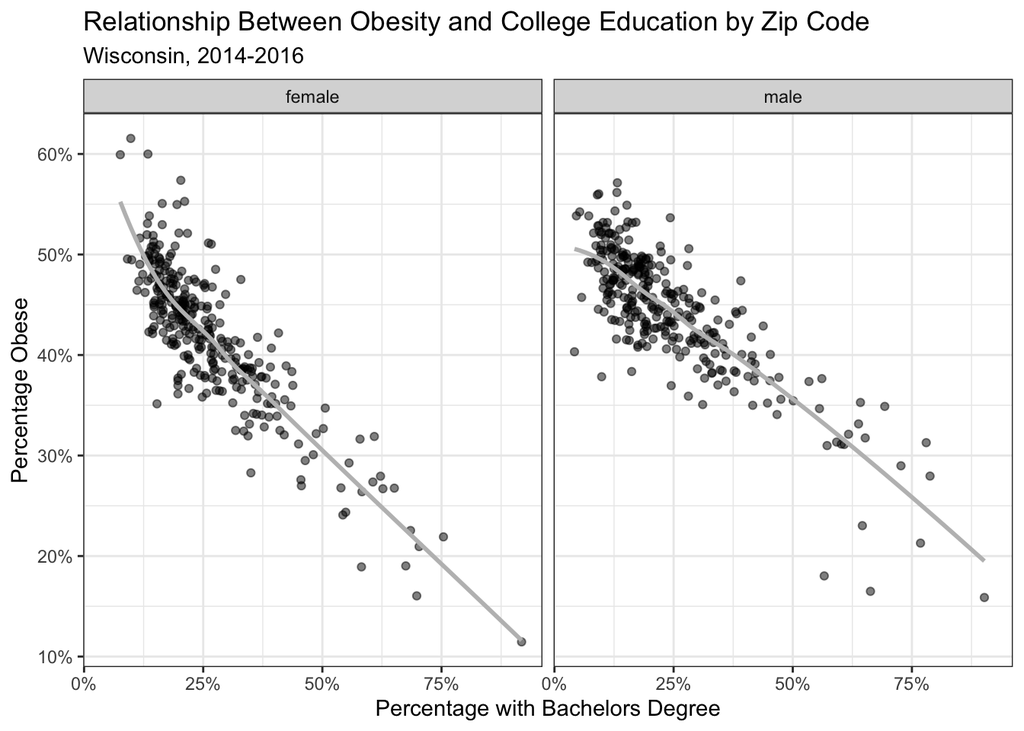

```r
g = ggplot(education_2, aes(x = w/100, y = y/100)) +
  geom_point(alpha = 0.5) +
  geom_smooth(se = FALSE, color = "gray") +
  xlab("") +
  ylab("") +
  scale_x_continuous(labels = scales::percent) +
  scale_y_continuous(labels = scales::percent) +
  facet_grid(cols = vars(sex)) +
  theme_bw()
```